# Syed_Imran_Saleem_DSBA_Project_EasyVisa_FullCode_v2.0

## EasyVisa Project

*Marks: 60*

## Problem Statement

### Context:

Business communities in the United States are facing high demand for human resources, but one of the constant challenges is identifying and attracting the right talent, which is perhaps the most important element in remaining competitive. Companies in the United States look for hard-working, talented, and qualified individuals both locally as well as abroad.

The Immigration and Nationality Act (INA) of the US permits foreign workers to come to the United States to work on either a temporary or permanent basis. The act also protects US workers against adverse impacts on their wages or working conditions by ensuring US employers' compliance with statutory requirements when they hire foreign workers to fill workforce shortages. The immigration programs are administered by the Office of Foreign Labor Certification (OFLC).

OFLC processes job certification applications for employers seeking to bring foreign workers into the United States and grants certifications in those cases where employers can demonstrate that there are not sufficient US workers available to perform the work at wages that meet or exceed the wage paid for the occupation in the area of intended employment.

### Objective:

In FY 2016, the OFLC processed 775,979 employer applications for 1,699,957 positions for temporary and permanent labor certifications. This was a nine percent increase in the overall number of processed applications from the previous year. The process of reviewing every case is becoming a tedious task as the number of applicants is increasing every year.

The increasing number of applicants every year calls for a Machine Learning based solution that can help in shortlisting the candidates having higher chances of VISA approval. OFLC has hired the firm EasyVisa for data-driven solutions. You as a data scientist at EasyVisa have to analyze the data provided and, with the help of a classification model:

- Facilitate the process of visa approvals.
- Recommend a suitable profile for the applicants for whom the visa should be certified or denied based on the drivers that significantly influence the case status.

### Data Description

The data contains the different attributes of employee and the employer. The detailed data dictionary is given below.

- case_id: ID of each visa application
- continent: Information of continent the employee
- education_of_employee: Information of education of the employee
- has_job_experience: Does the employee has any job experience? Y= Yes; N = No
- requires_job_training: Does the employee require any job training? Y = Yes; N = No
- no_of_employees: Number of employees in the employer's company
- yr_of_estab: Year in which the employer's company was established
- region_of_employment: Information of foreign worker's intended region of employment in the US.
- prevailing_wage: Average wage paid to similarly employed workers in a specific occupation in the area of intended employment. The purpose of the prevailing wage is to ensure that the foreign worker is not underpaid compared to other workers offering the same or similar service in the same area of employment.
- unit_of_wage: Unit of prevailing wage. Values include Hourly, Weekly, Monthly, and Yearly.
- full_time_position: Is the position of work full-time? Y = Full Time Position; N = Part Time Position
- case_status: Flag indicating if the Visa was certified or denied

### **Please read the instructions carefully before starting the project.**

This is a commented Jupyter IPython Notebook file in which all the instructions and tasks to be performed are mentioned.

- Blanks '**___**' are provided in the notebook that needs to be filled with an appropriate code to get the correct result. With every '**___**' blank, there is a comment that briefly describes what needs to be filled in the blank space.
- Identify the task to be performed correctly, and only then proceed to write the required code.
- Fill the code wherever asked by the commented lines like "# write your code here" or "# complete the code". Running incomplete code may throw error.
- Please run the codes in a sequential manner from the beginning to avoid any unnecessary errors.
- Add the results/observations (wherever mentioned) derived from the analysis in the presentation and submit the same.

## Importing necessary libraries

```python
import warnings

warnings.filterwarnings("ignore")

# Libraries to help with reading and manipulating data
import numpy as np
import pandas as pd

# Library to split data
from sklearn.model_selection import train_test_split

# libaries to help with data visualization
import matplotlib.pyplot as plt
import seaborn as sns

# Removes the limit for the number of displayed columns
pd.set_option("display.max_columns", None)
# Sets the limit for the number of displayed rows
pd.set_option("display.max_rows", 100)


# Libraries different ensemble classifiers
from sklearn.ensemble import (
    BaggingClassifier,
    RandomForestClassifier,
    AdaBoostClassifier,
    GradientBoostingClassifier,
    StackingClassifier,
)

from xgboost import XGBClassifier
from sklearn.tree import DecisionTreeClassifier

# Libraries to get different metric scores
from sklearn import metrics
from sklearn.metrics import (
    confusion_matrix,
    accuracy_score,
    precision_score,
    recall_score,
    f1_score,
)

# To tune different models
from sklearn.model_selection import GridSearchCV
```

## Importing Dataset

```python
from google.colab import drive
drive.mount('/content/drive')
visa = pd.read_csv('/content/drive/My Drive/Python Course/EasyVisa.csv')
visa.head()
```

|  | case_id | continent | education_of_employee | has_job_experience | requires_job_training | no_of_employees | yr_of_estab | region_of_employment | prevailing_wage | unit_of_wage | full_time_position | case_status |
| --- | --- | --- | --- | --- | --- | --- | --- | --- | --- | --- | --- | --- |
| 0 | EZYV01 | Asia | High School | N | N | 14513 | 2007 | West | 592.2029 | Hour | Y | Denied |
| 1 | EZYV02 | Asia | Master's | Y | N | 2412 | 2002 | Northeast | 83425.6500 | Year | Y | Certified |
| 2 | EZYV03 | Asia | Bachelor's | N | Y | 44444 | 2008 | West | 122996.8600 | Year | Y | Denied |
| 3 | EZYV04 | Asia | Bachelor's | N | N | 98 | 1897 | West | 83434.0300 | Year | Y | Denied |
| 4 | EZYV05 | Africa | Master's | Y | N | 1082 | 2005 | South | 149907.3900 | Year | Y | Certified |

```python
# copying data to another variable to avoid any changes to original data
data = visa.copy()
```

## Overview of the Dataset

### View the first and last 5 rows of the dataset

```python
data.head() ##   code to view top 5 rows of the data
```

|  | case_id | continent | education_of_employee | has_job_experience | requires_job_training | no_of_employees | yr_of_estab | region_of_employment | prevailing_wage | unit_of_wage | full_time_position | case_status |
| --- | --- | --- | --- | --- | --- | --- | --- | --- | --- | --- | --- | --- |
| 0 | EZYV01 | Asia | High School | N | N | 14513 | 2007 | West | 592.2029 | Hour | Y | Denied |
| 1 | EZYV02 | Asia | Master's | Y | N | 2412 | 2002 | Northeast | 83425.6500 | Year | Y | Certified |
| 2 | EZYV03 | Asia | Bachelor's | N | Y | 44444 | 2008 | West | 122996.8600 | Year | Y | Denied |
| 3 | EZYV04 | Asia | Bachelor's | N | N | 98 | 1897 | West | 83434.0300 | Year | Y | Denied |
| 4 | EZYV05 | Africa | Master's | Y | N | 1082 | 2005 | South | 149907.3900 | Year | Y | Certified |

```python
data.tail() ##   code to view last 5 rows of the data
```

|  | case_id | continent | education_of_employee | has_job_experience | requires_job_training | no_of_employees | yr_of_estab | region_of_employment | prevailing_wage | unit_of_wage | full_time_position | case_status |
| --- | --- | --- | --- | --- | --- | --- | --- | --- | --- | --- | --- | --- |
| 25475 | EZYV25476 | Asia | Bachelor's | Y | Y | 2601 | 2008 | South | 77092.57 | Year | Y | Certified |
| 25476 | EZYV25477 | Asia | High School | Y | N | 3274 | 2006 | Northeast | 279174.79 | Year | Y | Certified |
| 25477 | EZYV25478 | Asia | Master's | Y | N | 1121 | 1910 | South | 146298.85 | Year | N | Certified |
| 25478 | EZYV25479 | Asia | Master's | Y | Y | 1918 | 1887 | West | 86154.77 | Year | Y | Certified |
| 25479 | EZYV25480 | Asia | Bachelor's | Y | N | 3195 | 1960 | Midwest | 70876.91 | Year | Y | Certified |

### Understand the shape of the dataset

```python
data.shape##  code to view dimensions of the data
```

```
(25480, 12)
```

**Observations** there are about 25480 rows and 12 columns in the dataset

### Check the data types of the columns for the dataset

```python
data.info()
```

```
<class 'pandas.core.frame.DataFrame'>
RangeIndex: 25480 entries, 0 to 25479
Data columns (total 12 columns):
 #   Column                 Non-Null Count  Dtype
---  ------                 --------------  -----
 0   case_id                25480 non-null  object
 1   continent              25480 non-null  object
 2   education_of_employee  25480 non-null  object
 3   has_job_experience     25480 non-null  object
 4   requires_job_training  25480 non-null  object
 5   no_of_employees        25480 non-null  int64
 6   yr_of_estab            25480 non-null  int64
 7   region_of_employment   25480 non-null  object
 8   prevailing_wage        25480 non-null  float64
 9   unit_of_wage           25480 non-null  object
 10  full_time_position     25480 non-null  object
 11  case_status            25480 non-null  object
dtypes: float64(1), int64(2), object(9)
memory usage: 2.3+ MB
```

**Observations** there are no null data in the dataset ; except no_of_employees, yr_of_estab, prevailing_wage, all columns have object as datatype

```python
# checking for duplicate values
data.duplicated().sum()
```

```
0
```

**Observations** no duplicates in the dataset

## Exploratory Data Analysis

#### Let's check the statistical summary of the data

```python
data.describe().T ##   code to print the statistical summary of the data
```

|  | count | mean | std | min | 25% | 50% | 75% | max |
| --- | --- | --- | --- | --- | --- | --- | --- | --- |
| no_of_employees | 25480.0 | 5667.043210 | 22877.928848 | -26.0000 | 1022.00 | 2109.00 | 3504.0000 | 602069.00 |
| yr_of_estab | 25480.0 | 1979.409929 | 42.366929 | 1800.0000 | 1976.00 | 1997.00 | 2005.0000 | 2016.00 |
| prevailing_wage | 25480.0 | 74455.814592 | 52815.942327 | 2.1367 | 34015.48 | 70308.21 | 107735.5125 | 319210.27 |

**Observations**

#### Fixing the negative values in number of employees columns

```python
data.loc[data['no_of_employees'] <0].shape
```

```
(33, 12)
```

**Observations** there are 33 records with negative no_of_employees value

```python
# taking the absolute values for number of employees
data["no_of_employees"] = abs(data["no_of_employees"]) ## function to convert the values to a positive number
```

```python
data[data['no_of_employees'] <0].shape
```

```
(0, 12)
```

**Observations** now there are no more negative values in no_of_employees column

#### Let's check the count of each unique category in each of the categorical variables

```python
# Making a list of all categorical variables
cat_col = list(data.select_dtypes("object").columns)

# Printing number of count of each unique value in each column
for column in cat_col:
    print(data[column].value_counts())
    print("-" * 50)
```

```
EZYV01       1
EZYV16995    1
EZYV16993    1
EZYV16992    1
EZYV16991    1
            ..
EZYV8492     1
EZYV8491     1
EZYV8490     1
EZYV8489     1
EZYV25480    1
Name: case_id, Length: 25480, dtype: int64
--------------------------------------------------
Asia             16861
Europe            3732
North America     3292
South America      852
Africa             551
Oceania            192
Name: continent, dtype: int64
--------------------------------------------------
Bachelor's     10234
Master's        9634
High School     3420
Doctorate       2192
Name: education_of_employee, dtype: int64
--------------------------------------------------
Y    14802
N    10678
Name: has_job_experience, dtype: int64
--------------------------------------------------
N    22525
Y     2955
Name: requires_job_training, dtype: int64
--------------------------------------------------
Northeast    7195
South        7017
West         6586
Midwest      4307
Island        375
Name: region_of_employment, dtype: int64
--------------------------------------------------
Year     22962
Hour      2157
Week       272
Month       89
Name: unit_of_wage, dtype: int64
--------------------------------------------------
Y    22773
N     2707
Name: full_time_position, dtype: int64
--------------------------------------------------
Certified    17018
Denied        8462
Name: case_status, dtype: int64
--------------------------------------------------
```

**Observations** above shows all various unique values in each column

1. case status has 2 values (certified with 17018 rows, denied with 8462 rows)
2. full time postiion has 2 values (y with 22773 rows and n with 2707 rows)
3. unit_of_wage has 4 unique values (year, hour, month and week)
4. Region_of_employment is across 5 different regions
5. education_of_employees has 4 categories (bachelors, masters, high school and doctorate)

```python
# checking the number of unique values
data["case_id"].nunique ## code to check unique values in the mentioned column
```

```
<bound method IndexOpsMixin.nunique of 0           EZYV01
1           EZYV02
2           EZYV03
3           EZYV04
4           EZYV05
           ...
25475    EZYV25476
25476    EZYV25477
25477    EZYV25478
25478    EZYV25479
25479    EZYV25480
Name: case_id, Length: 25480, dtype: object>
```

**Observations** there are 25480 unique values of case id

```python
data.drop(["case_id"], axis=1, inplace=True) ## code to drop 'case_id' column from the data
```

```python
data.describe().T
```

|  | count | mean | std | min | 25% | 50% | 75% | max |
| --- | --- | --- | --- | --- | --- | --- | --- | --- |
| no_of_employees | 25480.0 | 5667.089207 | 22877.917453 | 11.0000 | 1022.00 | 2109.00 | 3504.0000 | 602069.00 |
| yr_of_estab | 25480.0 | 1979.409929 | 42.366929 | 1800.0000 | 1976.00 | 1997.00 | 2005.0000 | 2016.00 |
| prevailing_wage | 25480.0 | 74455.814592 | 52815.942327 | 2.1367 | 34015.48 | 70308.21 | 107735.5125 | 319210.27 |

### Univariate Analysis

```python
#function to plot histogram boxplot
def histogram_boxplot(data, feature, figsize=(15, 10), kde=False, bins=None):
    """
    Boxplot and histogram combined

    data: dataframe
    feature: dataframe column
    figsize: size of figure (default (15,10))
    kde: whether to show the density curve (default False)
    bins: number of bins for histogram (default None)
    """
    f2, (ax_box2, ax_hist2) = plt.subplots(
        nrows=2,  # Number of rows of the subplot grid= 2
        sharex=True,  # x-axis will be shared among all subplots
        gridspec_kw={"height_ratios": (0.25, 0.75)},
        figsize=figsize,
    )  # creating the 2 subplots
    sns.boxplot(
        data=data, x=feature, ax=ax_box2, showmeans=True, color="violet"
    )  # boxplot will be created and a triangle will indicate the mean value of the column
    sns.histplot(
        data=data, x=feature, kde=kde, ax=ax_hist2, bins=bins
    ) if bins else sns.histplot(
        data=data, x=feature, kde=kde, ax=ax_hist2
    )  # For histogram
    ax_hist2.axvline(
        data[feature].mean(), color="green", linestyle="--"
    )  # Add mean to the histogram
    ax_hist2.axvline(
        data[feature].median(), color="black", linestyle="-"
    )  # Add median to the histogram
```

#### Observations on number of employees

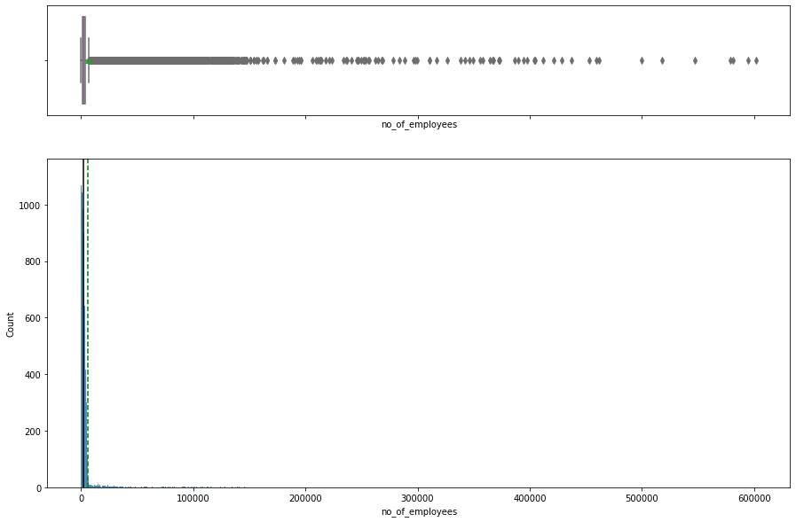

```python
histogram_boxplot(data, "no_of_employees")
```

**Observations** no_of_employees seems to have outliers, with average around 5667; min around 11; max around 602069 & 75th percentile around 3504

#### Observations on prevailing wage

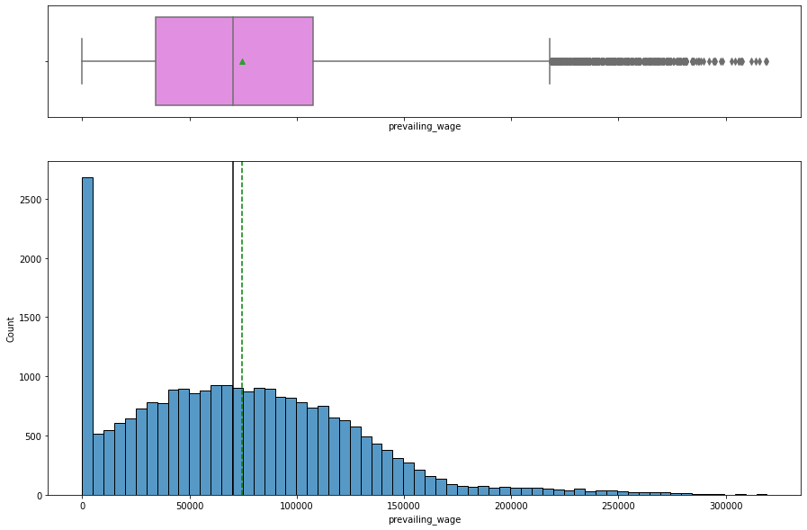

```python
histogram_boxplot(data, 'prevailing_wage') ## code to create histogram_boxplot for prevailing wage
```

**Observations** Upper fence of Prevailing wage has some outliers observed; with mean around 74K ; min around 2$ (per hourly basis); 75th percentile around 108K & max around 319K

```python
# checking the observations which have less than 100 prevailing wage
data.loc[data['prevailing_wage']<100] ## code to find the rows with less than 100 prevailing wage
```

|  | continent | education_of_employee | has_job_experience | requires_job_training | no_of_employees | yr_of_estab | region_of_employment | prevailing_wage | unit_of_wage | full_time_position | case_status |
| --- | --- | --- | --- | --- | --- | --- | --- | --- | --- | --- | --- |
| 338 | Asia | Bachelor's | Y | N | 2114 | 2012 | Northeast | 15.7716 | Hour | Y | Certified |
| 634 | Asia | Master's | N | N | 834 | 1977 | Northeast | 3.3188 | Hour | Y | Denied |
| 839 | Asia | High School | Y | N | 4537 | 1999 | West | 61.1329 | Hour | Y | Denied |
| 876 | South America | Bachelor's | Y | N | 731 | 2004 | Northeast | 82.0029 | Hour | Y | Denied |
| 995 | Asia | Master's | N | N | 302 | 2000 | South | 47.4872 | Hour | Y | Certified |
| ... | ... | ... | ... | ... | ... | ... | ... | ... | ... | ... | ... |
| 25023 | Asia | Bachelor's | N | Y | 3200 | 1994 | South | 94.1546 | Hour | Y | Denied |
| 25258 | Asia | Bachelor's | Y | N | 3659 | 1997 | South | 79.1099 | Hour | Y | Denied |
| 25308 | North America | Master's | N | N | 82953 | 1977 | Northeast | 42.7705 | Hour | Y | Denied |
| 25329 | Africa | Bachelor's | N | N | 2172 | 1993 | Northeast | 32.9286 | Hour | Y | Denied |
| 25461 | Asia | Master's | Y | N | 2861 | 2004 | West | 54.9196 | Hour | Y | Denied |

176 rows × 11 columns

**Observations**

1. 176 rows with prevailing wage < 100

```python
data.loc[data["prevailing_wage"] < 100, "unit_of_wage"].value_counts() ## code to get the count of the values in the mentioned column
```

```
Hour    176
Name: unit_of_wage, dtype: int64
```

**Observations**

1. There are about 176 records with prevailing wage < 100 and they are all hourly wages.

```python
# function to create labeled barplots


def labeled_barplot(data, feature, perc=False, n=None):
    """
    Barplot with percentage at the top

    data: dataframe
    feature: dataframe column
    perc: whether to display percentages instead of count (default is False)
    n: displays the top n category levels (default is None, i.e., display all levels)
    """

    total = len(data[feature])  # length of the column
    count = data[feature].nunique()
    if n is None:
        plt.figure(figsize=(count + 2, 6))
    else:
        plt.figure(figsize=(n + 2, 6))

    plt.xticks(rotation=90, fontsize=15)
    ax = sns.countplot(
        data=data,
        x=feature,
        palette="Paired",
        order=data[feature].value_counts().index[:n],
    )

    for p in ax.patches:
        if perc == True:
            label = "{:.1f}%".format(
                100 * p.get_height() / total
            )  # percentage of each class of the category
        else:
            label = p.get_height()  # count of each level of the category

        x = p.get_x() + p.get_width() / 2  # width of the plot
        y = p.get_height()  # height of the plot

        ax.annotate(
            label,
            (x, y),
            ha="center",
            va="center",
            size=12,
            xytext=(0, 5),
            textcoords="offset points",
        )  # annotate the percentage

    plt.show()  # show the plot
```

#### Observations on continent

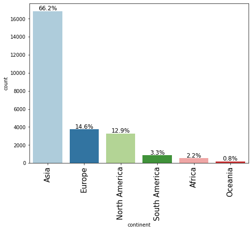

```python
labeled_barplot(data, "continent", perc=True)
```

**Observations**

1. Labelled barplot shows Asia is the highest in the list with 66.2%
2. Next in the list is Europe with 14.6%
3. Followed by North America with 12.9%
4. Last in the list is Oceania with 0.8%

#### Observations on education of employee

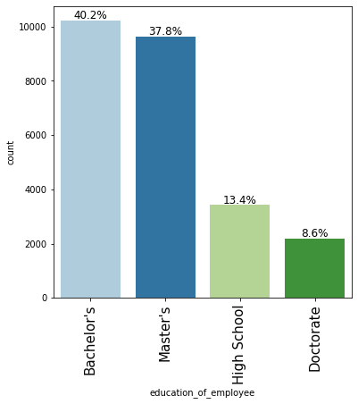

```python
labeled_barplot( data , "education_of_employee", perc=True)   ## code to create labeled_barplot for education of employee
```

**Observations**

1. Education of employee field labelled barplot shows Bachelors count is the highest with 40.2% followed by Masters with 37.8%
2. Doctorate is the lowest one with 8.6%

#### Observations on job experience

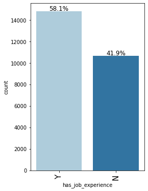

```python
labeled_barplot(data , 'has_job_experience', perc =True)  ## code to create labeled_barplot for job experience
```

**Observations**

1. Job Experience labelled barplot shows, Employees with experience is quite high almost around 58.1% followed by employees with no experience with just 41.9%

#### Observations on job training

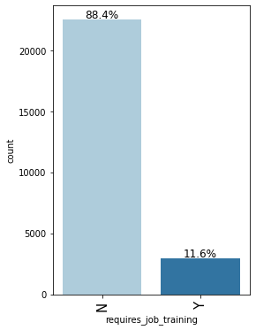

```python
labeled_barplot(data, 'requires_job_training', perc =True)  ## code to create labeled_barplot for job training
```

**Observations**

1. Requires_job_training = 'No' count is higher with almost 88.4% compared to Requires_job_training = 'Yes' with just 11.6%

#### Observations on region of employment

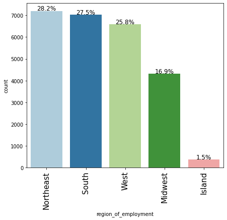

```python
labeled_barplot(data, 'region_of_employment', perc =True)  ## code to create labeled_barplot for region of employment
```

**Observations**

1. NorthEast region is the highest with 28.2% followed by South with 27.5%
2. West bags the 3rd position with 25.8%
3. Midwest bags the 4rth with 16.9% followed by Island being the last one with just 1.5%

#### Observations on unit of wage

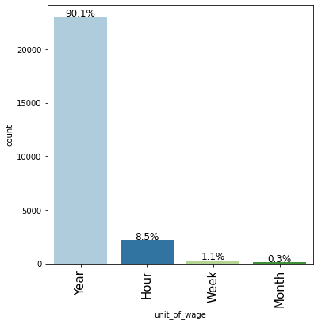

```python
labeled_barplot(data, 'unit_of_wage', perc =True)  ## code to create labeled_barplot for unit of wage
```

**Observations**

1. Unit of wage ='Year' has the highest count with 90.1% followed by Hourly wage with 8.5%
2. Weekly is 3rd in the position with 1.1% followed by Monthly with just 0.3%

#### Observations on case status

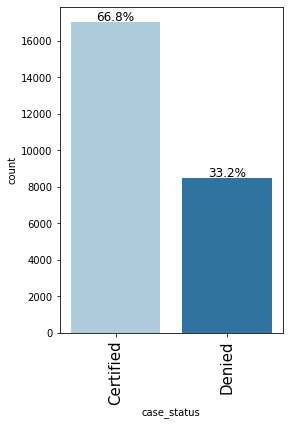

```python
labeled_barplot(data, 'case_status', perc =True)  ## code to create labeled_barplot for case status
```

**Observations**

1. Certfiied case status has the highest in the list with 66.8% followed by denied ones with 33.2%

### Bivariate Analysis

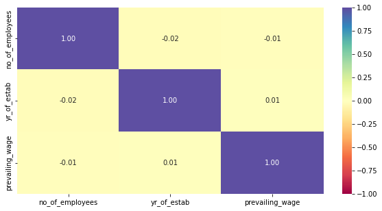

```python
#heatmap correlation on numeric columns
cols_list = data.select_dtypes(include=np.number).columns.tolist()

plt.figure(figsize=(10, 5))
sns.heatmap(
    data[cols_list].corr(), annot=True, vmin=-1, vmax=1, fmt=".2f", cmap="Spectral"
) ## code to find the correlation between the variables
plt.show()
```

**Observations**

1. No good correlations is observed based on the heat map
2. no_of_employees vs years of estab shows negative correlation with -0.02
3. prevailing wage vs years of estab shows very little correlation of 0.01
4. prevailing wage vs no of employees shows negative correlation of -0.01

**Creating functions that will help us with further analysis.**

```python
### function to plot distributions wrt target


def distribution_plot_wrt_target(data, predictor, target):

    fig, axs = plt.subplots(2, 2, figsize=(12, 10))

    target_uniq = data[target].unique()

    axs[0, 0].set_title("Distribution of target for target=" + str(target_uniq[0]))
    sns.histplot(
        data=data[data[target] == target_uniq[0]],
        x=predictor,
        kde=True,
        ax=axs[0, 0],
        color="teal",
        stat="density",
    )

    axs[0, 1].set_title("Distribution of target for target=" + str(target_uniq[1]))
    sns.histplot(
        data=data[data[target] == target_uniq[1]],
        x=predictor,
        kde=True,
        ax=axs[0, 1],
        color="orange",
        stat="density",
    )

    axs[1, 0].set_title("Boxplot w.r.t target")
    sns.boxplot(data=data, x=target, y=predictor, ax=axs[1, 0], palette="gist_rainbow")

    axs[1, 1].set_title("Boxplot (without outliers) w.r.t target")
    sns.boxplot(
        data=data,
        x=target,
        y=predictor,
        ax=axs[1, 1],
        showfliers=False,
        palette="gist_rainbow",
    )

    plt.tight_layout()
    plt.show()
```

```python
# function to define stacked barplot

def stacked_barplot(data, predictor, target):
    """
    Print the category counts and plot a stacked bar chart

    data: dataframe
    predictor: independent variable
    target: target variable
    """
    count = data[predictor].nunique()
    sorter = data[target].value_counts().index[-1]
    tab1 = pd.crosstab(data[predictor], data[target], margins=True).sort_values(
        by=sorter, ascending=False
    )
    print(tab1)
    print("-" * 120)
    tab = pd.crosstab(data[predictor], data[target], normalize="index").sort_values(
        by=sorter, ascending=False
    )
    tab.plot(kind="bar", stacked=True, figsize=(count + 5, 5))
    plt.legend(
        loc="lower left", frameon=False,
    )
    plt.legend(loc="upper left", bbox_to_anchor=(1, 1))
    plt.show()
```

#### Educational impact on visa certification

```
case_status            Certified  Denied    All
education_of_employee
All                        17018    8462  25480
Bachelor's                  6367    3867  10234
High School                 1164    2256   3420
Master's                    7575    2059   9634
Doctorate                   1912     280   2192
------------------------------------------------------------------------------------------------------------------------
```

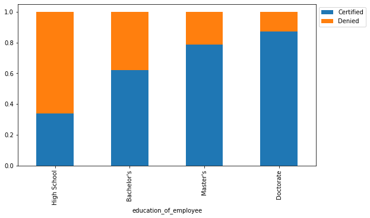

```python
stacked_barplot(data, "education_of_employee", "case_status")
```

**Observations on Case Status vs Education of Employee**

1. Employees who have High School education have higher denial numbers
2. Employees who have Doctorate education had very little denial numbers and higher certified numbers
3. Employees who have bachelors education have 60% certified numbers with 40% denials
4. Employees who have masters degree have 20% denial with 80% certified

#### Different regions vs educational backgrounds analysis

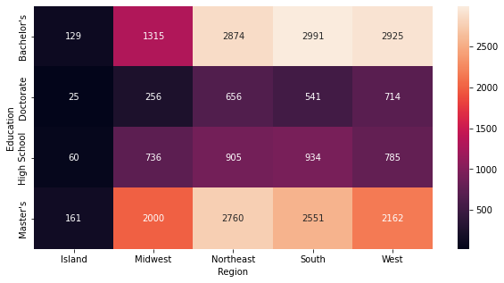

```python
plt.figure(figsize=(10, 5))
sns.heatmap(pd.crosstab(data['education_of_employee'], data['region_of_employment']),
    annot=True,
    fmt="g",
) ## code to plot heatmap for the crosstab between education and region of employment

plt.ylabel("Education")
plt.xlabel("Region")
plt.show()
```

**Observations on HeatMap of Education vs Region**

#### Percentage of visa certifications across each region

```
case_status           Certified  Denied    All
region_of_employment
All                       17018    8462  25480
Northeast                  4526    2669   7195
West                       4100    2486   6586
South                      4913    2104   7017
Midwest                    3253    1054   4307
Island                      226     149    375
------------------------------------------------------------------------------------------------------------------------
```

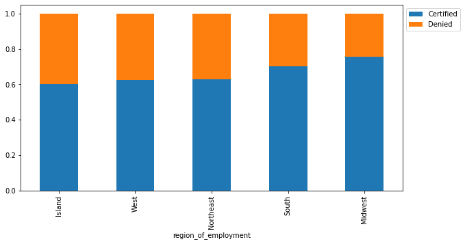

```python
stacked_barplot(data,'region_of_employment',  'case_status') ## code to plot stacked barplot for region of employment and case status
```

**Observations**

Continents impact analysis on visa status across different continents.

```
case_status    Certified  Denied    All
continent
All                17018    8462  25480
Asia               11012    5849  16861
North America       2037    1255   3292
Europe              2957     775   3732
South America        493     359    852
Africa               397     154    551
Oceania              122      70    192
------------------------------------------------------------------------------------------------------------------------
```

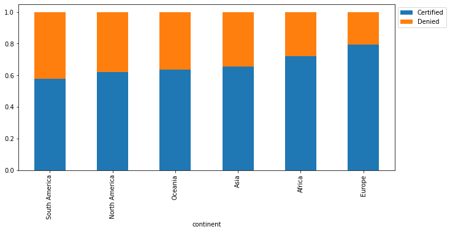

```python
stacked_barplot(data, 'continent', 'case_status') ## code to plot stacked barplot for continent and case status
```

**Observations**

1. Europe region has lower denial rates compared to certified rates (denial ratio around : 20; certified ratio around: 80 )
2. Africa region has lower denial rates compared to certified rates (denial ratio around : 30; certified ratio around: 70 )
3. Asia region has lower denial rates compared to certified rates (denial ratio around : 36; certified ratio around: 64 )
4. Oceania region has lower denial rates compared to certified rates (denial ratio around : 34; certified ratio around: 66 )
5. North America region has lower denial rates compared to certified rates (denial ratio around : 40; certified ratio around: 60 )
6. South America region has lower denial rates compared to certified rates (denial ratio around : 42; certified ratio around: 58 )

#### Work experience influence over visa certification

```
case_status         Certified  Denied    All
has_job_experience
All                     17018    8462  25480
N                        5994    4684  10678
Y                       11024    3778  14802
------------------------------------------------------------------------------------------------------------------------
```

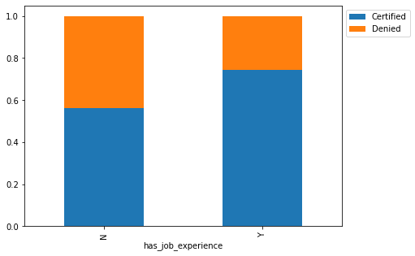

```python
stacked_barplot(data,  'has_job_experience', 'case_status') ## code to plot stacked barplot for job experience and case status
```

**Observations**

1. Has_Job_Experience ='Y' has lower denial rates compared to certified rates (denial ratio around : 24; certified ratio around: 76 )
2. Has_Job_Experience ='N' has lower denial rates compared to certified rates (denial ratio around : 42; certified ratio around: 58 )

#### Prior work experience vs any job training analysis

```
requires_job_training      N     Y    All
has_job_experience
All                    22525  2955  25480
N                       8988  1690  10678
Y                      13537  1265  14802
------------------------------------------------------------------------------------------------------------------------
```

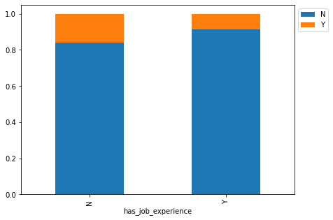

```python
stacked_barplot(data, 'has_job_experience', 'requires_job_training') ## code to plot stacked barplot for job experience and requires_job_training
```

**Observations**

1. One who has experience has lower ratio of requiring job training(requires training ratio around : 10; no require job training ratio around: 90)
2. One who has no experience has lower ratio of requiring job training (requires training ratio around : 18; no require job training ratio around: 82)

#### Prevailing wage determination against visa status changes analysis

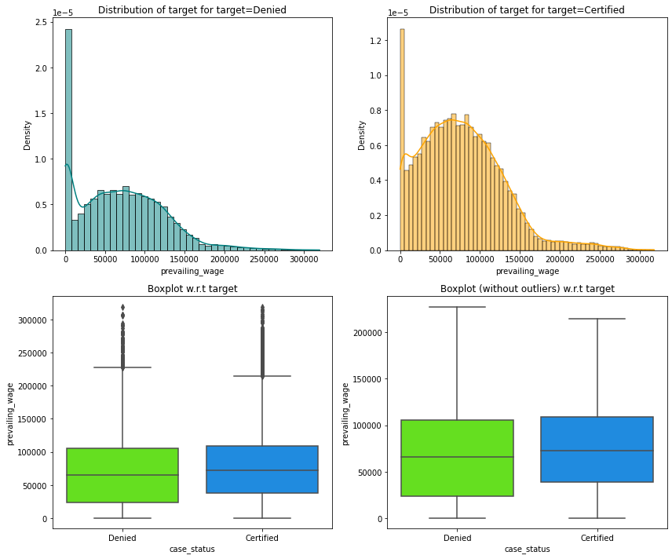

```python
distribution_plot_wrt_target(data, 'prevailing_wage', 'case_status') ## code to find distribution of prevailing wage and case status
```

**Observations**

1. Case Status vs Prevailing Wage comparison (without outliers) shows; Denial average is around 70000 prevailing wage
2. Case Status vs Prevailing Wage comparison (without outliers) shows; Certified average is slightly higher around 75000 prevailing wage

#### Prevailing wage across all the regions of the US

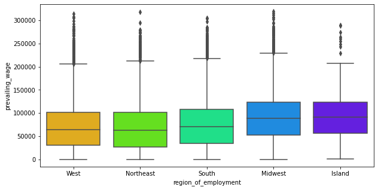

```python
plt.figure(figsize=(10, 5))
sns.boxplot(data = data  ,  x='region_of_employment', y= 'prevailing_wage',
            palette="gist_rainbow"
            )  ## code to create boxplot for region of employment and prevailing wage
plt.show()
```

**Observations**

1. Island region of employment shows an average of prevailing wage of 86K
2. midwest region of employment shows an average of prevailing wage of 85K
3. South region of employment shows an average of prevailing wage of 75K
4. NorthEast region of employment shows an average of prevailing wage of 70K
5. West region of employment shows an average of prevailing wage of 70K

#### The prevailing wage has different units (Hourly, Weekly, etc). Let's find out if it has any impact on visa applications getting certified.

```
case_status   Certified  Denied    All
unit_of_wage
All               17018    8462  25480
Year              16047    6915  22962
Hour                747    1410   2157
Week                169     103    272
Month                55      34     89
------------------------------------------------------------------------------------------------------------------------
```

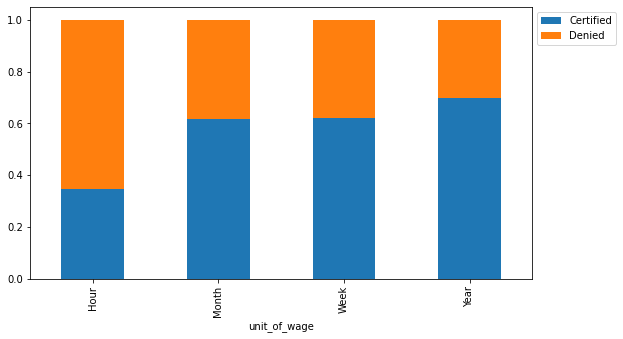

```python
stacked_barplot(data, 'unit_of_wage', 'case_status') ## code to plot stacked barplot for unit of wage and case status
```

**Observations**

1. Yearly wage has lower ratio of denial compared to certified(denial ratio around : 30; certified ratio around : 70)
2. Weekly wage has lower ratio of denial compared to certified(denial ratio around : 40; certified ratio around : 60)
3. Monthly wage has lower ratio of denial compared to certified(denial ratio around : 40; certified ratio around : 60)
4. Hourly wage has higher ratio of denial compared to certified(denial ratio around : 62; certified ratio around : 38)

## Data Preprocessing

### Outlier Check

- Let's check for outliers in the data.

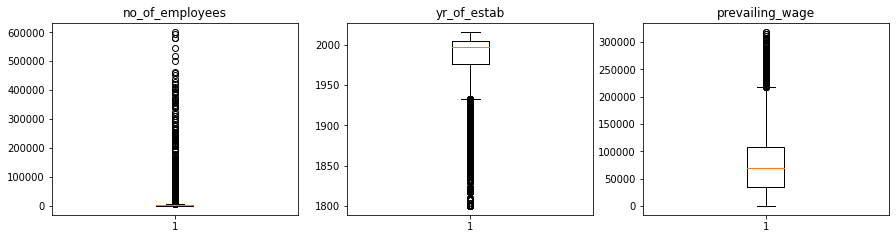

```python
# outlier detection using boxplot
numeric_columns = data.select_dtypes(include=np.number).columns.tolist()


plt.figure(figsize=(15, 12))

for i, variable in enumerate(numeric_columns):
    plt.subplot(3, 3, i + 1)
    plt.boxplot(data[variable])  ## code to create boxplots for all the numeric columns
    plt.title(variable)
plt.show()
```

**Observations**

1. no_of_employees has significant amount of outliers -- However, since this is about small scale to big scale companies, it could be possible that certain companies can have more employees compared to others, Hence this is not an outlier and is proper data.
2. yr_of_estab has significant amount of outliers -- However, since this is about small scale to big scale companies, it could be possible that certain companies could have been established pretty early than any new compaines, Hence this is not an outlier and is proper data.
3. prevailing wage has outlier as well -- prevailing wage could also be depending upon the position to which the company has filed for visa, hence possible depending on the employee position and wages, prevailing wage could also be higher or lower significantly, Hence this is not an outlier as well and is proper value

### Data Preparation for modeling

- We want to predict which visa will be certified.
- Before we proceed to build a model, we'll have to encode categorical features.
- We'll split the data into train and test to be able to evaluate the model that we build on the train data.

```python
# converting case status in terms of numeric ; 1 for certified and 0 for denied
data["case_status"] = data["case_status"].apply(lambda x: 1 if x == "Certified" else 0)

X = data.drop(['case_status'], axis =1) ## code to drop case status from the data
Y = data["case_status"]

X = pd.get_dummies(X, drop_first=True)  ## code to create dummies for X

# Splitting data in train and test sets
X_train, X_test, y_train, y_test = train_test_split(X,Y, test_size=0.30, random_state=1, stratify=Y) ## code to split the data into train and test in the ratio 70:30
```

```python
print("Shape of Training set : ", X_train.shape)
print("Shape of test set : ", X_test.shape)
print("Percentage of classes in training set:")
print(y_train.value_counts(normalize=True))
print("Percentage of classes in test set:")
print(y_test.value_counts(normalize=True))
```

```
Shape of Training set :  (17836, 21)
Shape of test set :  (7644, 21)
Percentage of classes in training set:
1    0.667919
0    0.332081
Name: case_status, dtype: float64
Percentage of classes in test set:
1    0.667844
0    0.332156
Name: case_status, dtype: float64
```

## Model evaluation criterion

### Model can make wrong predictions as:

1. Model predicts that the visa application will get certified but in reality, the visa application should get denied.
2. Model predicts that the visa application will not get certified but in reality, the visa application should get certified.

### Which case is more important?

- Both the cases are important as:
- If a visa is certified when it had to be denied a wrong employee will get the job position while US citizens will miss the opportunity to work on that position.
- If a visa is denied when it had to be certified the U.S. will lose a suitable human resource that can contribute to the economy.

### How to reduce the losses?

- `F1 Score` can be used a the metric for evaluation of the model, greater the F1 score higher are the chances of minimizing False Negatives and False Positives.
- We will use balanced class weights so that model focuses equally on both classes.

**First, let's create functions to calculate different metrics and confusion matrix so that we don't have to use the same code repeatedly for each model.**

- The model_performance_classification_sklearn function will be used to check the model performance of models.
- The confusion_matrix_sklearn function will be used to plot the confusion matrix.

```python
# defining a function to compute different metrics to check performance of a classification model built using sklearn


def model_performance_classification_sklearn(model, predictors, target):
    """
    Function to compute different metrics to check classification model performance

    model: classifier
    predictors: independent variables
    target: dependent variable
    """

    # predicting using the independent variables
    pred = model.predict(predictors)

    acc = accuracy_score(target, pred)  # to compute Accuracy
    recall = recall_score(target, pred)  # to compute Recall
    precision = precision_score(target, pred)  # to compute Precision
    f1 = f1_score(target, pred)  # to compute F1-score

    # creating a dataframe of metrics
    df_perf = pd.DataFrame(
        {"Accuracy": acc, "Recall": recall, "Precision": precision, "F1": f1,},
        index=[0],
    )

    return df_perf
```

```python
def confusion_matrix_sklearn(model, predictors, target):
    """
    To plot the confusion_matrix with percentages

    model: classifier
    predictors: independent variables
    target: dependent variable
    """
    y_pred = model.predict(predictors)
    cm = confusion_matrix(target, y_pred)
    labels = np.asarray(
        [
            ["{0:0.0f}".format(item) + "\n{0:.2%}".format(item / cm.flatten().sum())]
            for item in cm.flatten()
        ]
    ).reshape(2, 2)

    plt.figure(figsize=(6, 4))
    sns.heatmap(cm, annot=labels, fmt="")
    plt.ylabel("True label")
    plt.xlabel("Predicted label")
```

## Decision Tree - Model Building and Hyperparameter Tuning

### Decision Tree Model

```python
model = DecisionTreeClassifier(random_state=1) ## code to define decision tree classifier with random state = 1
model.fit(X_train, y_train) ## code to fit decision tree classifier on the train data
```

```
DecisionTreeClassifier(random_state=1)
```

#### Checking model performance on training set

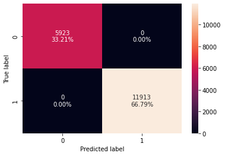

```python
confusion_matrix_sklearn(model, X_train, y_train) ## code to create confusion matrix for train data
```

```python
decision_tree_perf_train = model_performance_classification_sklearn(model, X_train, y_train) ## code to check performance on train data
decision_tree_perf_train
```

|  | Accuracy | Recall | Precision | F1 |
| --- | --- | --- | --- | --- |
| 0 | 1.0 | 1.0 | 1.0 | 1.0 |

#### Checking model performance on test set

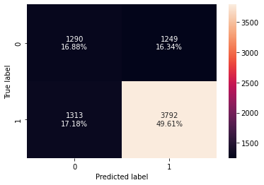

```python
confusion_matrix_sklearn(model, X_test, y_test) ## code to create confusion matrix for test data
```

```python
decision_tree_perf_test = model_performance_classification_sklearn(model, X_test, y_test) ## code to check performance for test data
decision_tree_perf_test
```

|  | Accuracy | Recall | Precision | F1 |
| --- | --- | --- | --- | --- |
| 0 | 0.664835 | 0.742801 | 0.752232 | 0.747487 |

**Observations**

1. Desicion tree is overfitting the training data as all scores are 1.0 (accuracy , precision, recall and f1 is 1.0)

### Hyperparameter Tuning - Decision Tree

```python
# Choose the type of classifier.
dtree_estimator = DecisionTreeClassifier(class_weight="balanced", random_state=1)

# Grid of parameters to choose from
parameters = {
    "max_depth": np.arange(5, 16, 5),
    "min_samples_leaf": [3, 5, 7],
    "max_leaf_nodes": [2, 5],
    "min_impurity_decrease": [0.0001, 0.001],
}

# Type of scoring used to compare parameter combinations
scorer = metrics.make_scorer(metrics.f1_score)

# Run the grid search
grid_obj = GridSearchCV(dtree_estimator, parameters, scoring=scorer, n_jobs=-1) ## code to run grid search with n_jobs = -1

grid_obj = grid_obj.fit(X_train, y_train) ## code to fit the grid_obj on the train data

# Set the clf to the best combination of parameters
dtree_estimator = grid_obj.best_estimator_

# Fit the best algorithm to the data.
dtree_estimator.fit(X_train, y_train)
```

```
DecisionTreeClassifier(class_weight='balanced', max_depth=5, max_leaf_nodes=2,
                       min_impurity_decrease=0.0001, min_samples_leaf=3,
                       random_state=1)
```

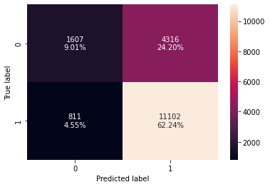

```python
confusion_matrix_sklearn(dtree_estimator, X_train, y_train)## code to create confusion matrix for train data on tuned estimator
```

```python
dtree_estimator_model_train_perf = model_performance_classification_sklearn(dtree_estimator,X_train, y_train) ## code to check performance for train data on tuned estimator
dtree_estimator_model_train_perf
```

|  | Accuracy | Recall | Precision | F1 |
| --- | --- | --- | --- | --- |
| 0 | 0.712548 | 0.931923 | 0.720067 | 0.812411 |

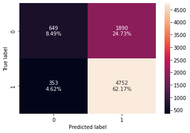

```python
confusion_matrix_sklearn(dtree_estimator, X_test, y_test) ## code to create confusion matrix for test data on tuned estimator
```

```python
dtree_estimator_model_test_perf = model_performance_classification_sklearn(dtree_estimator, X_test, y_test) ## code to check performance for test data on tuned estimator
dtree_estimator_model_test_perf
```

|  | Accuracy | Recall | Precision | F1 |
| --- | --- | --- | --- | --- |
| 0 | 0.706567 | 0.930852 | 0.715447 | 0.809058 |

**Observations**

1. The overfitting has reduced; model is performing quite well (As the scores for training and test are comparable)
2. f1 score on test is almost 81% ;

However lets try to see if we can further tune this model to have better performance and scores

## Bagging - Model Building and Hyperparameter Tuning

### Bagging Classifier

```python
bagging_classifier = BaggingClassifier(random_state=1) ## code to define bagging classifier with random state = 1
bagging_classifier.fit(X_train, y_train) ## code to fit bagging classifier on the train data
```

```
BaggingClassifier(random_state=1)
```

#### Checking model performance on training set

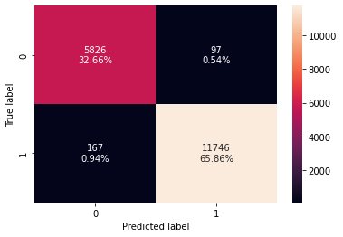

```python
confusion_matrix_sklearn(bagging_classifier, X_train, y_train) ## code to create confusion matrix for train data
```

```python
bagging_classifier_model_train_perf = model_performance_classification_sklearn(bagging_classifier, X_train, y_train) ## code to check performance on train data
bagging_classifier_model_train_perf
```

|  | Accuracy | Recall | Precision | F1 |
| --- | --- | --- | --- | --- |
| 0 | 0.985198 | 0.985982 | 0.99181 | 0.988887 |

#### Checking model performance on test set

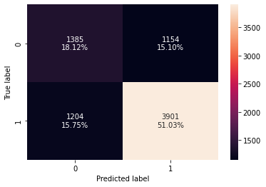

```python
confusion_matrix_sklearn(bagging_classifier, X_test, y_test) ## code to create confusion matrix for test data
```

```python
bagging_classifier_model_test_perf = model_performance_classification_sklearn(bagging_classifier, X_test, y_test) ## code to check performance for test data
bagging_classifier_model_test_perf
```

|  | Accuracy | Recall | Precision | F1 |
| --- | --- | --- | --- | --- |
| 0 | 0.691523 | 0.764153 | 0.771711 | 0.767913 |

**Observations**

1. Bagging classifier is overfitting the training data; Also test f1 score is low with just 77%
2. Training and Test data scores are not comparable here;

Let's try Bagging hyperparameter tuning and see if the model performance improves

### Hyperparameter Tuning - Bagging Classifier

```python
# Choose the type of classifier.
bagging_estimator_tuned = BaggingClassifier(random_state=1)

# Grid of parameters to choose from
parameters = {
    "max_samples": [0.7, 0.9],
    "max_features": [0.7, 0.9],
    "n_estimators": np.arange(90, 111, 10),
}

# Type of scoring used to compare parameter combinations
acc_scorer = metrics.make_scorer(metrics.f1_score)

# Run the grid search
grid_obj = GridSearchCV(bagging_estimator_tuned, parameters, scoring=acc_scorer, cv=5) ##  code to run grid search with cv = 5
grid_obj = grid_obj.fit(X_train, y_train) ##  code to fit the grid_obj on train data

# Set the clf to the best combination of parameters
bagging_estimator_tuned = grid_obj.best_estimator_

# Fit the best algorithm to the data.
bagging_estimator_tuned.fit(X_train, y_train)
```

```
BaggingClassifier(max_features=0.7, max_samples=0.7, n_estimators=100,
                  random_state=1)
```

#### Checking model performance on training set

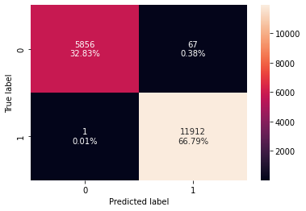

```python
confusion_matrix_sklearn(bagging_estimator_tuned, X_train, y_train) ##  code to create confusion matrix for train data on tuned estimator
```

```python
bagging_estimator_tuned_model_train_perf = model_performance_classification_sklearn(bagging_estimator_tuned, X_train, y_train) ## code to check performance for train data on tuned estimator
bagging_estimator_tuned_model_train_perf
```

|  | Accuracy | Recall | Precision | F1 |
| --- | --- | --- | --- | --- |
| 0 | 0.996187 | 0.999916 | 0.994407 | 0.997154 |

#### Checking model performance on test set

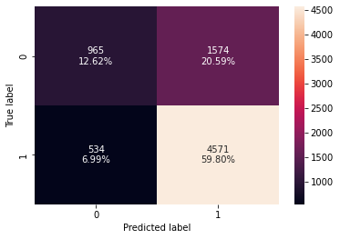

```python
confusion_matrix_sklearn(bagging_estimator_tuned, X_test, y_test) ##  code to create confusion matrix for test data on tuned estimator
```

```python
bagging_estimator_tuned_model_test_perf = model_performance_classification_sklearn(bagging_estimator_tuned, X_test, y_test) ## code to check performance for test data on tuned estimator
bagging_estimator_tuned_model_test_perf
```

|  | Accuracy | Recall | Precision | F1 |
| --- | --- | --- | --- | --- |
| 0 | 0.724228 | 0.895397 | 0.743857 | 0.812622 |

**Observations**

1. Bagging Tuned model is overfitting on training data; Training and Test scores are not comparable ;

Lets try Random Forest model tuning

### Random Forest

```python
# Fitting the model
rf_estimator = RandomForestClassifier(random_state=1) ##  code to define random forest with random state = 1 and class_weight = balanced
rf_estimator.fit(X_train, y_train) ##  code to fit random forest on the train data
```

```
RandomForestClassifier(random_state=1)
```

#### Checking model performance on training set

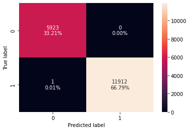

```python
 ## code to create confusion matrix for train data
 confusion_matrix_sklearn(rf_estimator, X_train, y_train)
```

```python
# Calculating different metrics
rf_estimator_model_train_perf = model_performance_classification_sklearn(rf_estimator, X_train, y_train) ## code to check performance on train data
rf_estimator_model_train_perf
```

|  | Accuracy | Recall | Precision | F1 |
| --- | --- | --- | --- | --- |
| 0 | 0.999944 | 0.999916 | 1.0 | 0.999958 |

#### Checking model performance on test set

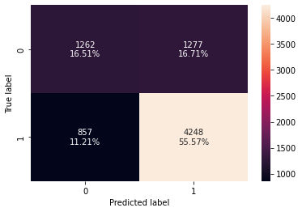

```python
confusion_matrix_sklearn(rf_estimator, X_test,y_test) ## code to create confusion matrix for test data
```

```python
rf_estimator_model_test_perf = model_performance_classification_sklearn(rf_estimator, X_test,y_test) ## code to check performance for test data
rf_estimator_model_test_perf
```

|  | Accuracy | Recall | Precision | F1 |
| --- | --- | --- | --- | --- |
| 0 | 0.720827 | 0.832125 | 0.768869 | 0.799247 |

**Observations**

1. random forest seems to be overfitting the training data ;
2. Training and test scores are not comparable

Lets try hypertuning on random forest to see if any better results

### Hyperparameter Tuning - Random Forest

```python
# Choose the type of classifier.
rf_tuned = RandomForestClassifier(random_state=1, oob_score=True, bootstrap=True)

parameters = {
    "max_depth": list(np.arange(5, 15, 5)),
    "max_features": ["sqrt", "log2"],
    "min_samples_split": [5, 7],
    "n_estimators": np.arange(15, 26, 5),
}

# Type of scoring used to compare parameter combinations
acc_scorer = metrics.make_scorer(metrics.f1_score)

# Run the grid search
grid_obj = GridSearchCV(rf_tuned, parameters, scoring=acc_scorer, cv =5, n_jobs=-1) ## code to run grid search with cv = 5 and n_jobs = -1
grid_obj = grid_obj.fit(X_train, y_train) ## code to fit the grid_obj on the train data

# Set the clf to the best combination of parameters
rf_tuned = grid_obj.best_estimator_

# Fit the best algorithm to the data.
rf_tuned.fit(X_train, y_train)
```

```
RandomForestClassifier(max_depth=10, max_features='sqrt', min_samples_split=7,
                       n_estimators=20, oob_score=True, random_state=1)
```

#### Checking model performance on training set

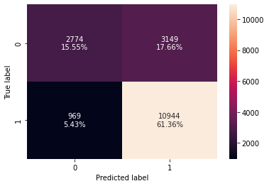

```python
confusion_matrix_sklearn(rf_tuned, X_train, y_train) ## code to create confusion matrix for train data on tuned estimator
```

```python
rf_tuned_model_train_perf = model_performance_classification_sklearn(rf_tuned, X_train, y_train) ## code to check performance for train data on tuned estimator
rf_tuned_model_train_perf
```

|  | Accuracy | Recall | Precision | F1 |
| --- | --- | --- | --- | --- |
| 0 | 0.769119 | 0.91866 | 0.776556 | 0.841652 |

#### Checking model performance on test set

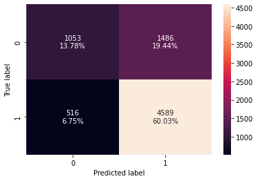

```python
confusion_matrix_sklearn(rf_tuned, X_test,y_test) ## code to create confusion matrix for test data on tuned estimator
```

```python
rf_tuned_model_test_perf = model_performance_classification_sklearn(rf_tuned, X_test,y_test) ## code to check performance for test data on tuned estimator
rf_tuned_model_test_perf
```

|  | Accuracy | Recall | Precision | F1 |
| --- | --- | --- | --- | --- |
| 0 | 0.738095 | 0.898923 | 0.755391 | 0.82093 |

**Observations** Observations are not bad; since test and train scores are comparable ; f1 score on test is around 82%

lets try boosting model and see if any better results